# Analysis of Marketing Campaign of loan and deposit in bank XYZ

Group S: 404 NOT FOUND; team members: Cheng Zhang, Zhaoyang Wang, Tianyi Zhang

April 29, 2019

# Introduction of Loan Marketing Campaign data sets

- Datasets are about a personal loan marketing campaign of HSBC.  
  Personal Loan is a product that allows customer lending money from the bank without any collateral. In the marketing campaigns, the bank will send loan information to selected customers, aiming at attract more customers apply loan product and increase the revenue.  
  We are working on projects in order to review and improve the campaign effectiveness. There are three datasets.
- Campaign List: Contains all the information of this campaign
- Lending Product Information: Historical loan usages and credit information of clients
- Customer Information: (6 tables for 6 months) Detailed features of clients which are somewhat relevant to the campaign

# Variables

- dummy_cus_key: Customers’ unique ID within the bank.
- channel: Different customer will receive the message through different channel. Phone Call: The contact channel with highest cost per contact. SMS: Text message. The cost is lower than phone call. Email: The contact channel with lowest cost per contact.
- contact_ind: ‘Y’ indicates: Phone Call: customer picked up the call. SMS: customer read the message. Email: customer opened the email. ‘N’ otherwise.
- response: Indicates whether a customer apply for a new loan account.
- loan_amount: Indicates the applied loan amount.

# Variables

- msk_ever_loan_user: Indicates customers who ever had any loan product.
- msk_instl_loan_user: Indicates customers who ever had personal loan product.
- msk_other_lending_user: Indicates customers who ever had other unsecured lending product.
- msk_unauth_over_card_limit: Indicates customers who ever had unauthorized over-limit of credit card.
- msk_mth_since_last_limit_review: Number of months since last credit card limit increase.
- msk_bank_tenor: Number of months since customers open their first account with the bank.

# Variables

- msk_mortgage: Indicates customers who are holding mortgage by month-end of the data month (1 or Y means “Yes”).
- msk_total_saving_bal: Total deposit balance (including demand deposit and time deposit) by month-end of the data month.
- msk_total_investment_bal: Total investment product balance by month-end of the data month.
- msk_hold_insurance_ind: Indicates customers who are holding insurance product by month-end of the data month (1 or Y means “Yes”).
- msk_credit_card_bill_bal: Credit card bill amount of the bill cycle in the data month.

# Variables

- msk_credit_card_limit: Credit card limit by month-end of the data month.
- msk_credit_card_revolving_bal: The credit card revolving balance carried over from previous bill cycles.
- msk_total_credit_trn_amount: Total transaction amount of cash withdrawal or transfer-out in the data month.
- msk_total_credit_trn_atm_amount: Total transaction amount of cash withdrawal or transfer-out via ATM in the data month.
- msk_total_credit_trn_count: Total transaction count of cash withdrawal or transfer-out in the data month.

# Variables

- msk_total_deposit_trn_count: Total transaction count of cash deposit or transfer-in in the data month.
- msk_age: Age.
- msk_education: Education level.
- msk_gender: Gender.
- msk_job: Job category.

# Shiny Interface

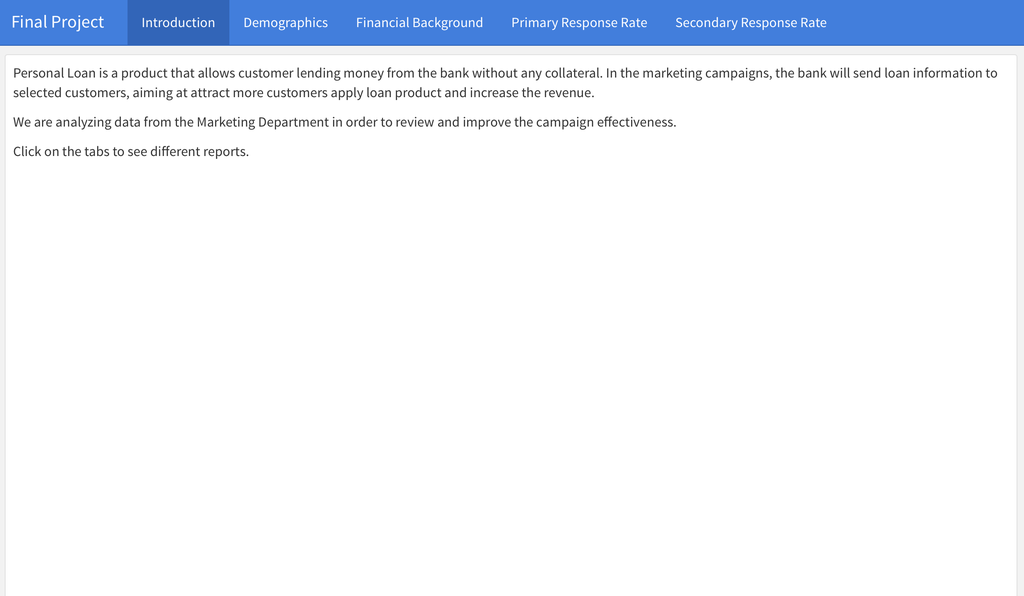

```r
knitr::include_graphics("snap.png")
```

# Shiny tabs

- Introduction: Overview of the project
- Demographics: Bar charts by demographic groups
- Financial Background: Client’s background on finance status
- Primary Response Rate: Whether a customer picks up the call, reads the message, opens the email or not.
- Secondary Response Rate: Whether a customer applies for a new loan account or not.

# Data cleaning and feature selection 1

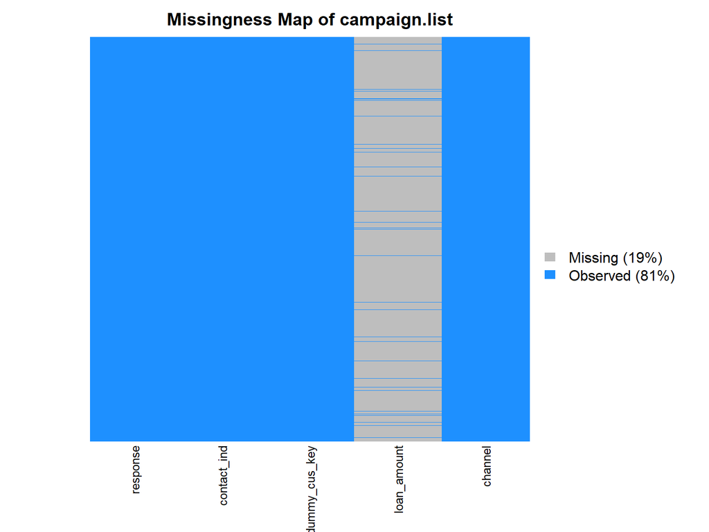

```r
library(Amelia)
missmap(data.frame(campaign.list), legend = T, col = c("grey", "dodgerblue"),
        rank.order=F,y.labels = NULL,y.at = NULL, main = "Missingness Map of campaign.list")
```

# Data cleaning and feature selection 2

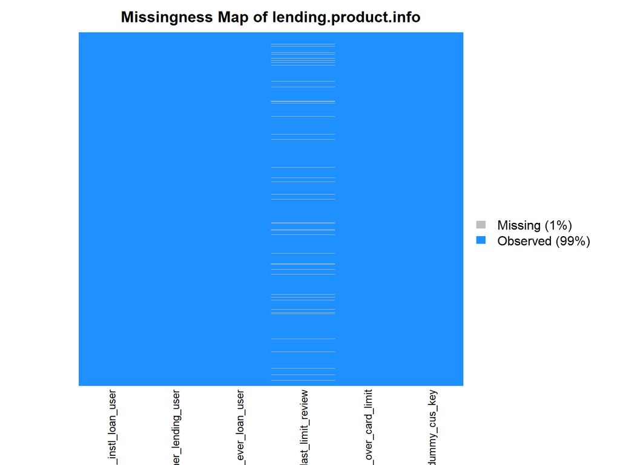

```r
missmap(data.frame(lending.product.info), legend = T, col = c("grey", "dodgerblue"),
        rank.order=F,y.labels = NULL,y.at = NULL, main = "Missingness Map of lending.product.info")
```

# Data cleaning and feature selection 3

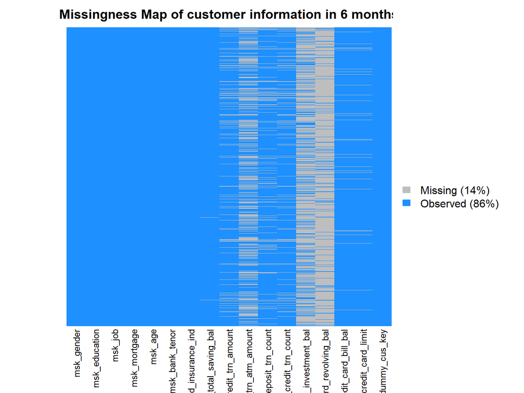

```r
missmap(data.frame(info), legend = T, col = c("grey", "dodgerblue"),
       rank.order=F,y.labels = NULL,y.at = NULL, main = "Missingness Map of customer information in 6 months")
```

# Data cleaning and feature selection 4

- the Customer Information datasets are unioned and merged with other datasets.
- We handle the missing data use different technics based on the meaning of each column and the numbers of missing data in each column.
- There are two features that are deleted since they have too many NAs  
  msk_total_investment_bal(Total investment product balance by month-end of the data month)  
  msk_credit_card_revolving_bal (The credit card revolving balance carried over from previous bill cycle)

# Data cleaning and feature selection 5

- An example of handling the missing data in one column
- msk_total_credit_trn_atm_amount(Total transaction amount of cash withdrawal or transfer-out via ATM in the data month)

```r
summary(info$msk_total_credit_trn_atm_amount)
```

```
   Min. 1st Qu.  Median    Mean 3rd Qu.    Max.    NA's
     10    3725    8037   12336   15387 4508001  279453
```

There are 279453 NAs. Since it’s nearly 30% percentage, if we fill them with mean, the original distribution of this column will be hugely changed. However, since the min value of this column is not 0 but 10, we assume that the NAs represent for no transaction. So, we fill the NAs with 0.

# Data cleaning and feature selection 6

- We find that there are many extreme large values, we need to delete those extreme values in some columns. If data is large than mean + 3*standard deviation then it is defined as outlier.

```r
delete.max <- c("msk_mth_since_last_limit_review","msk_age","msk_bank_tenor","msk_total_saving_bal","msk_total_credit_trn_amount","msk_total_credit_trn_atm_amount","msk_total_deposit_trn_count","msk_total_credit_trn_count","msk_credit_card_bill_bal","msk_credit_card_limit")

is.above <- function(x){
  return(x >= (mean(x, na.rm=T) + 3*sd(x, na.rm=T)))
}
rows.to.include <- rowMeans(x = total.final[, lapply(X = .SD, FUN = "is.above"), .SDcols = delete.max]) == 0
```

# Goals for data analysis

- Topic 1: Effectiveness of loan campaign: increase the response rate  
  Methods: logistic regression, random forest, adaboost
- Topic 2: Channel selection: Choose the best channel to contact selected clients.  
  Assumption: In the historical data. If the clients response, then the channel is regard as best channel for him.  
  Methods: random forest, adaboost
- Topic 3: Loan amount: Choose top clients with the highest loan amounts  
  Methods: linear regression, random forest

# Data processing for models

- There exists severe imbalance of “response” and “channel”. The sampling and resampling technics were used to handle this problem.
- Relevant datasets for topics are divided into training and testing set with a ratio of 7:3.
- Ten fold cross validation is used when we need to tune some hyperparameters for models.

# Topic1: Effectiveness of loan campaign

- The response rate is not high, we should find a way to improve that
- In the marketing situation, the thing we care more is the recall, since we try to select as many as the target clients. recall: TP / (TP+FN)

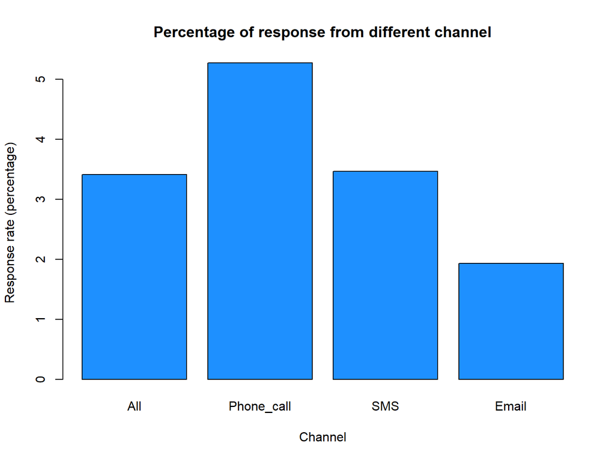

```r
barplot(height = 100*as.matrix(t(response)), names.arg = c("All","Phone_call","SMS","Email"),
        main = "Percentage of response from different channel",
        ylab = "Response rate (percentage)",
        xlab = "Channel",
        col="dodgerblue")
```

# imbalance of observation

```r
response <- dim(filtered.total.final1)[1]
not.response <- dim(filtered.total.final2)[1]
dt <- data.table(type=c("response","not.response"),c(response,not.response))
colnames(dt) <- c("type","num")
dt
```

```
           type    num
1:     response  22214
2: not.response 627987
```

In the training dataset, we want to make number of responded clients and number of not response to be balanced, so we will randomly select 22214 rows in the dataset of not responded clients to make the data balanced. Since the number of rows of very large, there is no need to use the resampling strategy, which will destroy the original distribution.

# Method 1: logistic regression with stepwise selection 1

- This model is for the explanation to our business patterners.
- Recall and accuracy are as follows.

```r
recall.logi
```

```
[1] 0.7515379
```

```r
accuracy.logi
```

```
[1] 0.754248
```

# Method 1: logistic regression with stepwise selection 2

- Odds ratios for all the features are as follows. We will draw some inference in our final report.

```r
odds.logi
```

```
                    (Intercept)            msk_instl_loan_userY
                      0.1964686                       1.7714977
             msk_ever_loan_user msk_mth_since_last_limit_review
                      3.3656140                       0.7784303
     msk_unauth_over_card_limit                  msk_genderMALE
                      1.3091678                       1.3352011
           msk_educationDIPLOMA        msk_educationHIGH SCHOOL
                      1.4758262                       2.0344994
             msk_educationOTHER msk_educationUNIVERSITY & ABOVE
                      1.8866482                       1.3411665
msk_jobMID/HIGH INCOME INDUSTRY                         msk_age
                      0.7000494                       0.6621433
                 msk_bank_tenor          msk_hold_insurance_ind
                      0.9446000                       0.8820753
           msk_total_saving_bal     msk_total_credit_trn_amount
                      0.5279364                       1.1280950
msk_total_credit_trn_atm_amount      msk_total_credit_trn_count
                      1.1490147                       1.3169297
       msk_credit_card_bill_bal           msk_credit_card_limit
                      1.2585074                       0.8844924
```

# Method 1: logistic regression with stepwise selection 3

- AUC value and ROC curve

```r
auc.logi
```

```
[1] 0.8338762
```

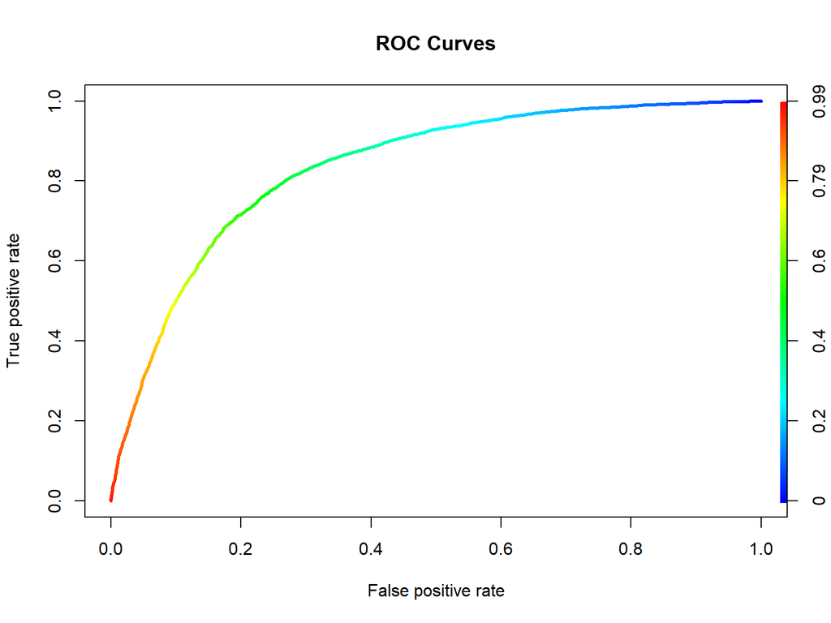

```r
plot(performance(pred.log.trans, "tpr", "fpr"), colorize = T, lwd = 3, main = "ROC Curves")
```

# Method 2: Random forset 1

- This model is for capture the nonlinear trend and improve the quality of production
- Recall and accuracy for test data

```r
rf.test.recall
```

```
[1] 0.8907727
```

```r
rf.test.accuracy
```

```
[1] 0.8853814
```

# Method 2: Random forset 2

- error plot when fitting the model

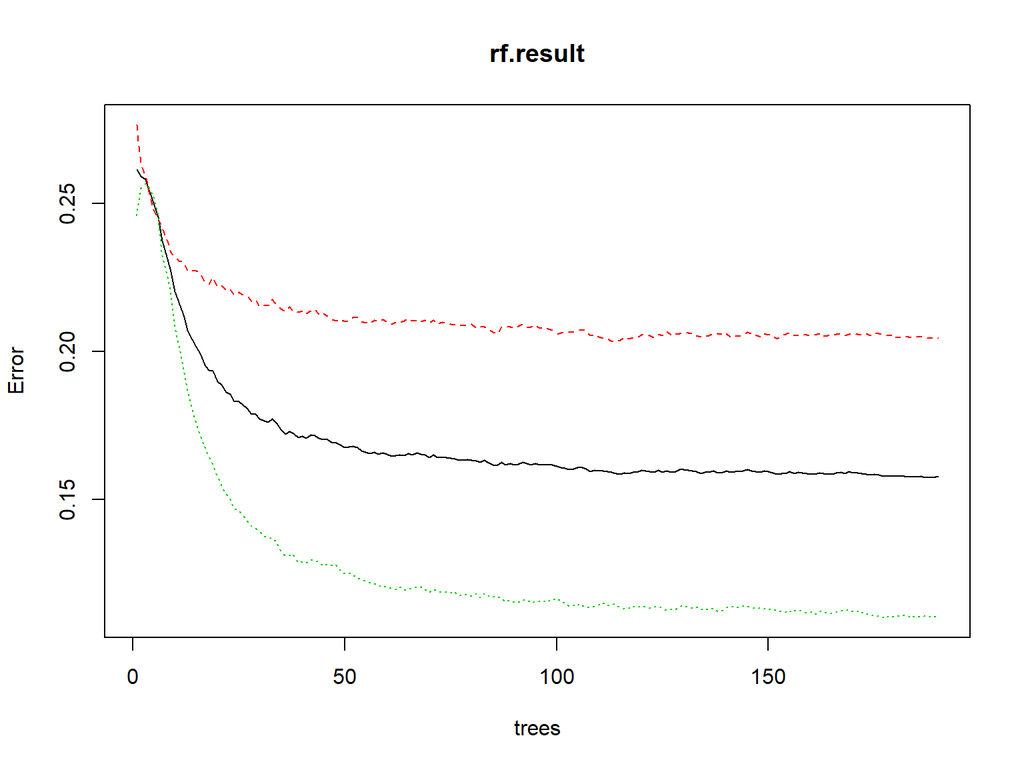

```r
plot(rf.result)
```

# Method 2: Random forset 3

- AUC value and ROC curve

```r
response.rf.auc
```

```
[1] 0.918467
```

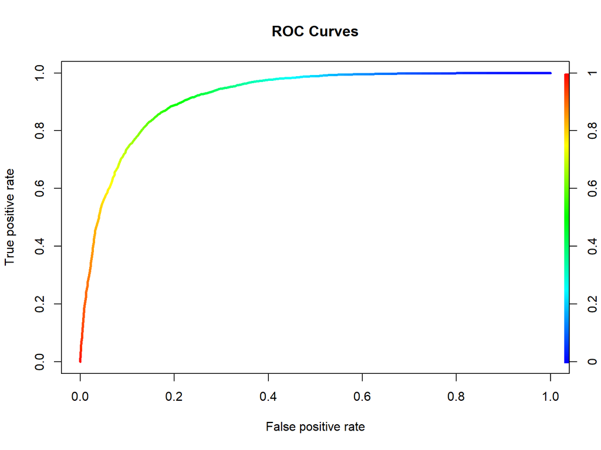

```r
plot(performance(pred.rf.trans, "tpr", "fpr"), colorize = T, lwd = 3, main = "ROC Curves")
```

# Method 2: Random forset 4

- The importance of all the features is as follows (Some inference will draw in the report)

```r
rf.importance
```

```
                                MeanDecreaseAccuracy
msk_instl_loan_user                         26.20139
msk_other_lending_user                      14.46865
msk_ever_loan_user                          83.48682
msk_mth_since_last_limit_review             98.89413
msk_unauth_over_card_limit                  33.26849
msk_gender                                  33.97589
msk_education                               67.24835
msk_job                                     37.66924
msk_mortgage                                31.77524
msk_age                                    102.44655
msk_bank_tenor                              97.27241
msk_hold_insurance_ind                      32.39676
msk_total_saving_bal                       179.59259
msk_total_credit_trn_amount                 74.98322
msk_total_credit_trn_atm_amount             59.13667
msk_total_deposit_trn_count                 49.39724
msk_total_credit_trn_count                  72.38369
msk_credit_card_bill_bal                   100.18129
msk_credit_card_limit                      100.52553
```

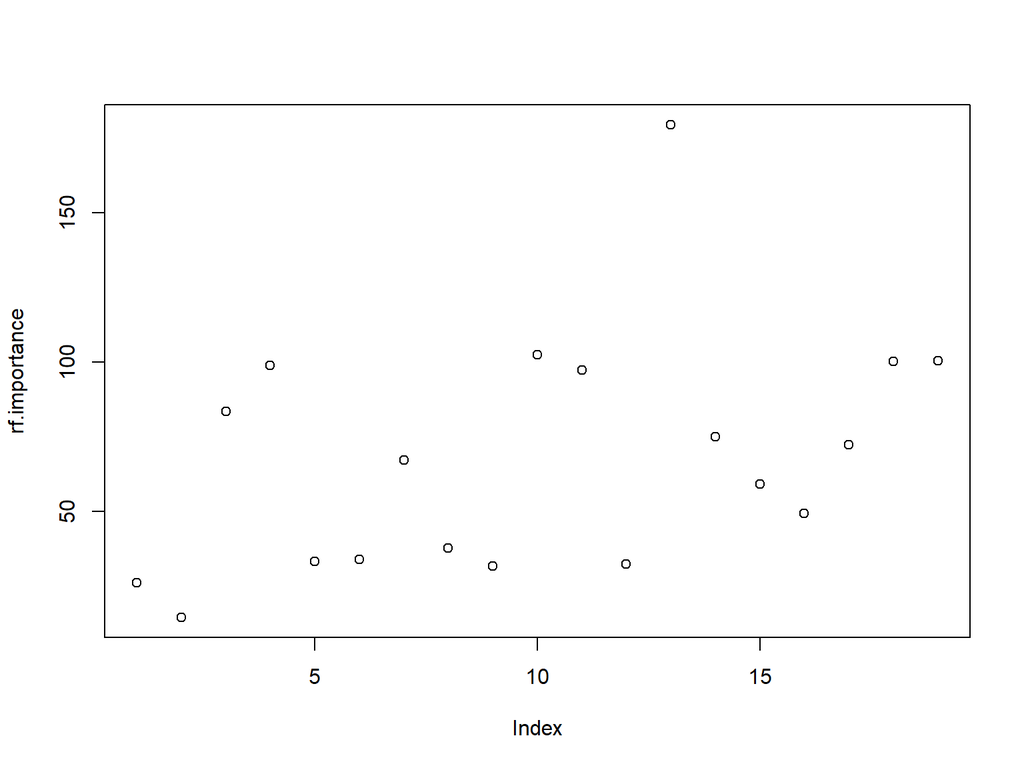

```r
plot(rf.importance)
```

# Method 2: Random forset 5

- Finally, we show the influence of model to the whole dataset to our out business partner
- Use the “lift”: When our target is the response rate, what we care more is how much the affiance is increased comparing to random select.
- Def of lift: recall of the model/accuracy of random select

```r
lift <- recall(Freq2)/response.rate.randomselect
lift
```

```
   response
1:   28.308
```

# Method 3: adaboost 1

- It has a great advantage of avoid overfitting and may have a better output
- It’s also friendly for business partners for they can directly run the code with new data without tuning parameters.

# Method 3: adaboost 2

- response, accuracy

```r
response.recall.ada
```

```
[1] 0.9338335
```

```r
response.accuracy.ada
```

```
[1] 0.929805
```

# Method 3: adaboost 3

- AUC and ROC curve

```r
response.auc.ada
```

[output not shown]

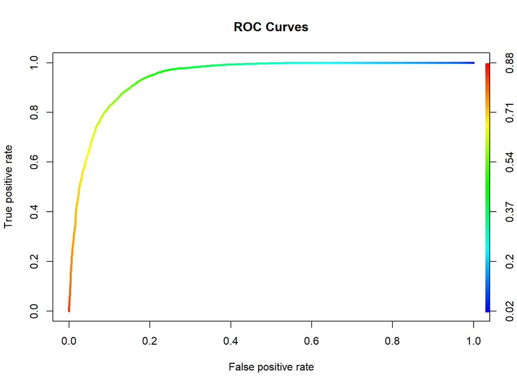

```r
plot(performance(pred.ada.trans, "tpr", "fpr"), colorize = T, lwd = 3, main = "ROC Curves")
```

# Method 3: adaboost 4

- Life when apply the modle in the whole dataset (Same situation with previous random forest model)

```r
response.lift.ada
```

```
   response
1: 28.30537
```

# Topic 2: Channel selection

- After getting the target user, the following question is how to connect them.
- We select those responded clients (with response=1, contact_ind=Y) and determine which channel are the best to contact those clients.
- In this part, the only thing we care about is the accuracy, so we don’t use any regression model.
- Assumption: In the historical data. If the clients response, then the channel is regard as best channel for him.  
  Methods: random forest, adaboost

# imbalance of data

- The data is imbalanced. Since the total number of rows is small, we use resampling to make them balance.

```r
channel.dat[, .N, by="channel"]
```

```
      channel    N
1: Phone Call 7680
2:      Email 1351
3:        SMS 4000
```

# Method 1: Random forest 1

- error plot when fitting the model

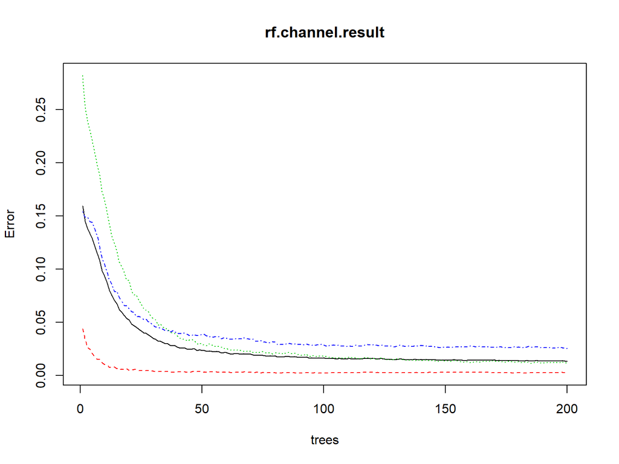

```r
plot(rf.channel.result)
```

# Method 1: Random forest 2

- importance of varibale

```r
rf.channel.importance
```

```
                                MeanDecreaseAccuracy
msk_instl_loan_user                         19.76754
msk_other_lending_user                      16.93209
msk_ever_loan_user                          21.33584
msk_mth_since_last_limit_review             69.95276
msk_unauth_over_card_limit                  34.10497
msk_gender                                  26.44265
msk_education                               56.28058
msk_job                                     40.34617
msk_mortgage                                29.77595
msk_age                                     47.26287
msk_bank_tenor                              59.31467
msk_hold_insurance_ind                      20.21049
msk_total_saving_bal                        60.90330
msk_total_credit_trn_amount                 61.59364
msk_total_credit_trn_atm_amount             41.23329
msk_total_deposit_trn_count                 47.53899
msk_total_credit_trn_count                  62.93329
msk_credit_card_bill_bal                    47.15823
msk_credit_card_limit                       75.13745
```

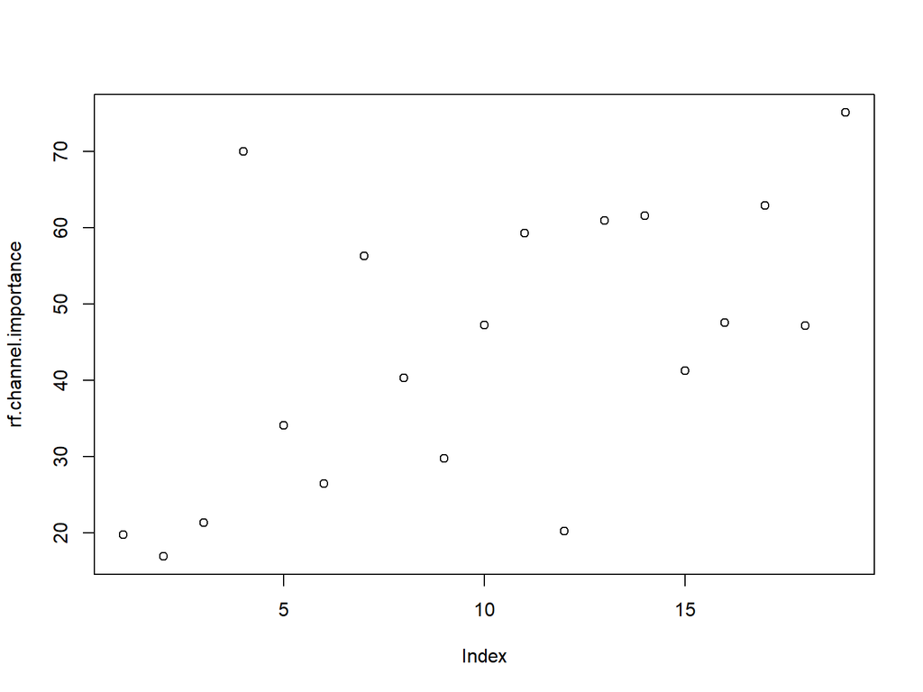

```r
plot(rf.channel.importance)
```

# Method 1: Random forest 3

- recall for each channel: email, phone, sms

```r
dt.recall <- data.frame(c(recall.email,recall.phone,recall.sms))
rownames(dt.recall) <- c("recall.email","recall.phone","recall.sms")
colnames(dt.recall) <- c("recall")
dt.recall
```

```
                recall
recall.email 0.9995656
recall.phone 0.9789880
recall.sms   0.9907814
```

```r
rf.accuracy
```

```
[1] 0.989728
```

- overall accuracy

```r
rf.accuracy
```

```
[1] 0.989728
```

# Method 2: Adaboost

- Original datasets are transform to three datasets with 0-1 represent the channel.
- Then three adaboost models are applied for three channels.
- Recall and accuracy for each channel.

```r
result
```

```
             phone     email       sms
recall   0.9839410 0.9978299 0.9683160
accuracy 0.9893125 0.9985541 0.9790681
```

# Topic 3: Loan amount: Choose top clients with the highest loan amounts

- Regardless of the risk management process, banks always prefer larger amount of single loan.
- Sometimes the loan campaign has a budget, we just can lend money to some of the target clients who are willing to borrow money.
- Besides, we won’t know how much our clients want to borrow unless we make future discussion with them.
- So, we need to predict loan amount for each before head.

# Method 1: Stepwise regression (For explaination)

- R-squared and parameters
- R-squared is the percentage of the dependent variable variation that a linear model explains.
- Some inference based on parameters will showed in report.

```r
summary(step.model.amount)$r.square
```

```
[1] 0.7708401
```

```r
step.model.amount$coefficients
```

```
                    (Intercept)            msk_instl_loan_userY
                    228876.4516                     -39832.9774
        msk_other_lending_userY              msk_ever_loan_user
                    -20871.9962                     -25761.7536
     msk_unauth_over_card_limit                  msk_genderMALE
                    -15750.5456                        723.0571
           msk_educationDIPLOMA        msk_educationHIGH SCHOOL
                     -8549.7987                     -11203.2520
             msk_educationOTHER msk_educationUNIVERSITY & ABOVE
                     -9852.7041                     -10504.3597
                  msk_mortgageY                         msk_age
                     -2243.2140                        849.3565
                 msk_bank_tenor            msk_total_saving_bal
                      -802.1979                      -1251.1021
    msk_total_deposit_trn_count        msk_credit_card_bill_bal
                       891.3494                        266.9873
          msk_credit_card_limit
                      -428.4393
```

# Method 2: Random forest for more accurate prediction 1

- The R-squared of stepwise regression model is relatively low.
- So, we need to use advance method which can identify some non-linear relationship and get more accurate prediction.
- For comparation, R-squared is also calculated for this model

```r
mse <- sum((pred-loan_amount.test.factor$loan_amount)^2)/(length(pred)-1)
rsq <- 1-(mse/var(pred))
rsq
```

```
[1] 0.9622969
```

# Method 2: Random forest for more accurate prediction 2

- error plot when fitting the model

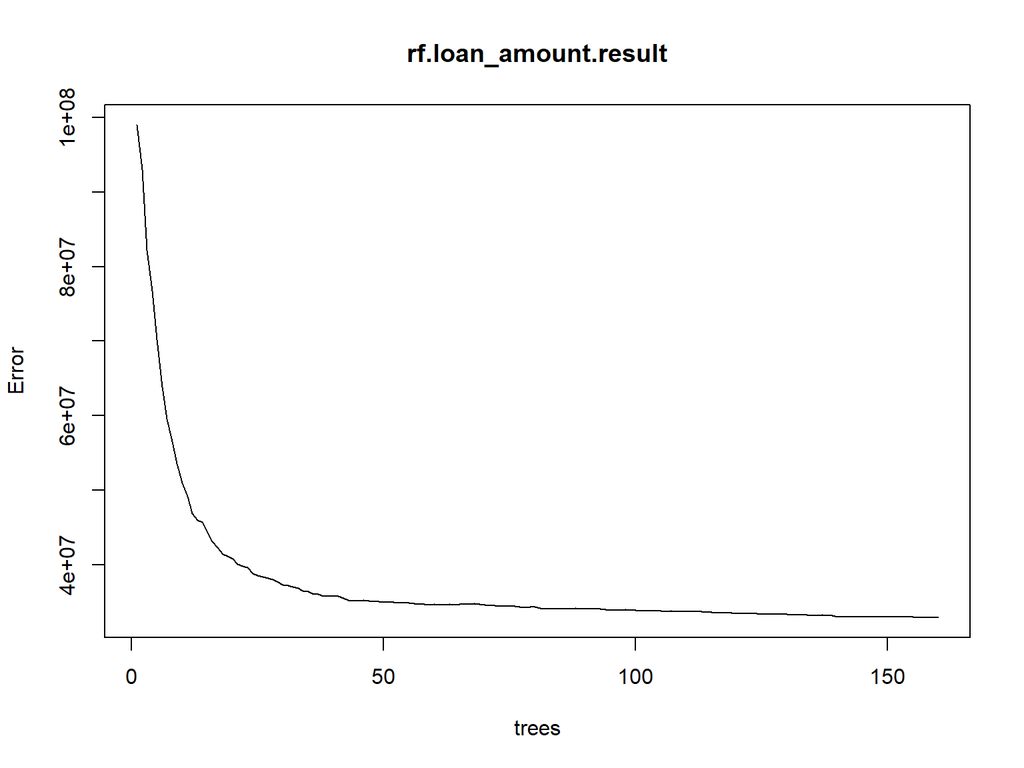

```r
plot(rf.loan_amount.result)
```

# Method 2: Random forest for more accurate prediction 3

- The importance of all features

```r
rf.loan_amount.importance
```

```
                                  %IncMSE
msk_instl_loan_user              29.50752
msk_other_lending_user          124.67716
msk_ever_loan_user               34.93654
msk_mth_since_last_limit_review  52.68285
msk_unauth_over_card_limit      208.89001
msk_gender                       26.38457
msk_education                    52.56344
msk_job                          21.90835
msk_mortgage                     20.36812
msk_age                          63.18642
msk_bank_tenor                   70.79169
msk_hold_insurance_ind           21.35161
msk_total_saving_bal             49.09913
msk_total_credit_trn_amount      32.18563
msk_total_credit_trn_atm_amount  33.68748
msk_total_deposit_trn_count      27.64425
msk_total_credit_trn_count       32.59543
msk_credit_card_bill_bal         42.06651
msk_credit_card_limit            56.56980
```

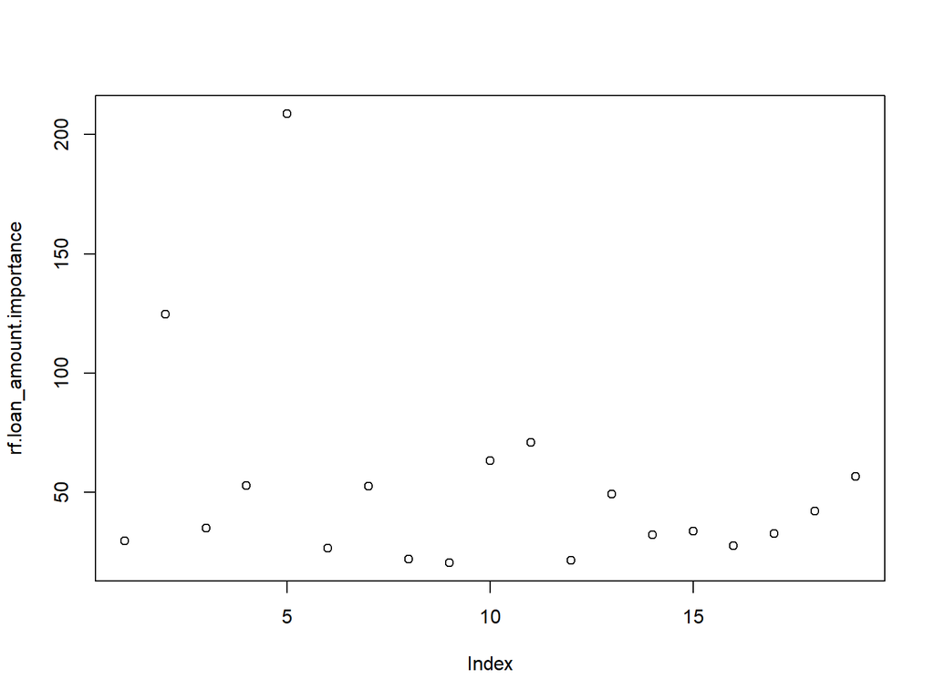

```r
plot(rf.loan_amount.importance)
```

# Method 2: Random forest for more accurate prediction 4

- Now, since the amount of deposit is limited, we only allowed to give 1000 clients the loan in this campaign. We need to find a way to target the clients who will borrow the largest amount of money.
- We will use the model in the whole unique dataset of loan_amount which contain all unique information of clients who get the loan and see the increase comparing to the random select.
- The increment is as follows. Besides, the less the number of chosen clients, the higher the increment will be.

```r
increase.percentage
```

```
[1] 37.43478
```

# Other ways to handle the limited budget?

- The limited budget shows the bank may in shortage of amount of liquidity and want to avoid potential liquidity risk.
- We don’t we lunch a deposit campaign to get more money.

# The next step for the data analysis

- We already get some historical data of the marketing campaign of deposit, because the bank have already aware of the liquidity risk and want to get more money.
- Unfortunately, Since the campaign just started, we just get the preliminary data with only one target variable: response  
  But we can still analysis that dataset to increase the efficiency of the deposit campaign.

# Information about Market Campaigns Data

- The data is related with direct marketing campaigns of a Portuguese banking institution.
- The marketing campaigns were based on phone calls. Often, more than one contact to the same client was required, in order to access if the product (bank term deposit) would be (‘yes’) or not (‘no’) subscribed

# Descriprion of Input Variables

- age: age of customers (numeric)
- job: type of job (categorical)
- marital: marital status (categorical)
- education: degree of education (categorical)
- default: has credit in default? (categorical)
- housing: has housing loan? (categorical)
- loan: has personal loan? (categorical)

# related with the last contact of the current campaign:

- contact: contact communication type (categorical)
- month: last contact month of year (categorical)
- day_of_week: last contact day of the week (categorical)
- duration: last contact duration, in seconds (numeric).

# other attributes:

- campaign: number of contacts performed during this campaign and for this client (numeric)
- pdays: number of days that passed by after the client was last contacted from a previous campaign (numeric)
- previous: number of contacts performed before this campaign and for this client (numeric)
- poutcome: outcome of the previous marketing campaign (categorical)

# social and economic context attributes

- emp.var.rate: employment variation rate - quarterly indicator (numeric)
- cons.price.idx: consumer price index - monthly indicator (numeric)
- cons.conf.idx: consumer confidence index - monthly indicator (numeric)
- euribor3m: euribor 3 month rate - daily indicator (numeric)
- nr.employed: number of employees - quarterly indicator (numeric)

# Date Cleaing

-Issue of value “unknown”

```r
dat[dat=="unknown"]<-NA
```

# Date Cleaing

-Issue of “default” variable

```r
dat[,.N,by=default.name]
```

```
   default     N
1:      no 32588
2:    <NA>  8597
3:     yes     3
```

Because so much NA value in this variable, we assume that “default” has no impact to output variable. Remove this variable from data.

```r
dat$default<-NULL
```

```r
dat[,.N,keyby=y.name]
```

```
     y     N
1:  no 36548
2: yes  4640
```

```r
dat[get(y.name) %in% "yes", eval(y.name) := "1"]
dat[get(y.name) %in% "no", eval(y.name) := "0"]
dat[, .N, keyby = y.name]
```

```
   y     N
1: 0 36548
2: 1  4640
```

```r
dat<-na.omit(dat)
```

```r
dim(dat)
```

```
[1] 38245    21
```

# Variable Selection

-Based on description of dataset, variables about clients have little impact to result,

```r
model_variable<-c(contact.name,day_of_week.name,campaign.name,previous.name,poutcome.name,emp.var.rate.name,cons.price.idx.name,cons.conf.idx.name,euribor3m.name,nr.employed.name)
```

```r
model.formula<-create.formula(y.name,model_variable)
```

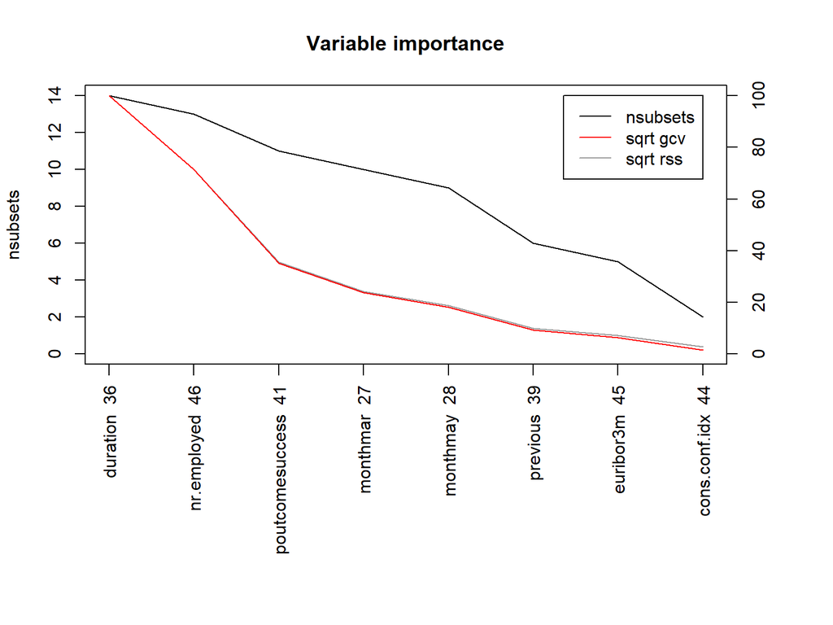

```r
library(earth)
model_var <-earth(y ~.,data=dat_train,glm=list(family=binomial))
ev <- evimp (model_var)
plot(ev)
```

# Logistic Regression Model

```r
library(glmnet)

logModel <- glm(model.formula, data=dat_train, family=binomial)
summary(logModel)
```

```
Call:
glm(formula = model.formula, family = binomial, data = dat_train)

Deviance Residuals:
    Min       1Q   Median       3Q      Max
-1.9045  -0.4244  -0.3210  -0.2783   2.9160

Coefficients:
                      Estimate Std. Error z value Pr(>|z|)
(Intercept)         -92.411501  18.300759  -5.050 4.43e-07 ***
contacttelephone     -0.974415   0.068146 -14.299  < 2e-16 ***
day_of_weekmon       -0.208667   0.071047  -2.937  0.00331 **
day_of_weekthu        0.076888   0.068324   1.125  0.26045
day_of_weektue        0.083593   0.070071   1.193  0.23288
day_of_weekwed        0.160110   0.069378   2.308  0.02101 *
campaign             -0.053783   0.011897  -4.521 6.16e-06 ***
previous              0.026120   0.069865   0.374  0.70850
poutcomenonexistent   0.596609   0.109692   5.439 5.36e-08 ***
poutcomesuccess       1.877134   0.097176  19.317  < 2e-16 ***
emp.var.rate         -0.745384   0.073712 -10.112  < 2e-16 ***
cons.price.idx        1.132704   0.119064   9.513  < 2e-16 ***
cons.conf.idx         0.042482   0.006781   6.265 3.72e-10 ***
euribor3m             0.116812   0.093467   1.250  0.21138
nr.employed          -0.002860   0.001663  -1.720  0.08540 .
---
Signif. codes:  0 '***' 0.001 '**' 0.01 '*' 0.05 '.' 0.1 ' ' 1

(Dispersion parameter for binomial family taken to be 1)

    Null deviance: 18923  on 26770  degrees of freedom
Residual deviance: 15228  on 26756  degrees of freedom
AIC: 15258

Number of Fisher Scoring iterations: 6
```

```r
log.pred<-predict(logModel, dat_test,type = "response")
mean(round(log.pred,0)==dat_test$y)
```

```
[1] 0.9028432
```

# ROC curve for Logistic Model

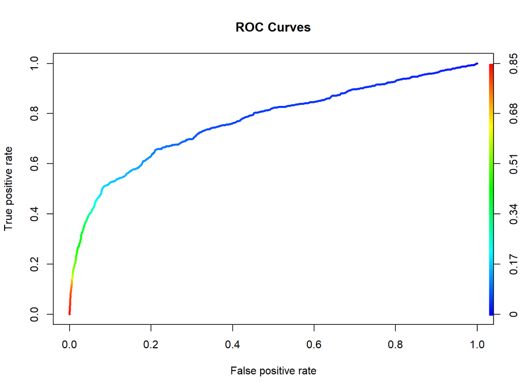

```r
library(ROCR)
pred.log.prob <- predict(logModel ,dat_test, type='response')
pred.log.trans <- prediction(pred.log.prob, dat_test$y)

auc.logi <- performance(pred.log.trans,'auc')@y.values[[1]]
# 0.8338762
plot(performance(pred.log.trans, "tpr", "fpr"), colorize = T, lwd = 3, main = "ROC Curves")
```

# SVM Model

```r
library(e1071)
svm.fit<-svm(`y` ~ `contact` + `day_of_week` + `campaign` + `previous` + `poutcome` + `emp.var.rate` + `cons.price.idx` + `cons.conf.idx` + `euribor3m` + `nr.employed`, data=dat_train)
summary(svm.fit)
```

```
Call:
svm(formula = y ~ contact + day_of_week + campaign + previous +
    poutcome + emp.var.rate + cons.price.idx + cons.conf.idx +
    euribor3m + nr.employed, data = dat_train)


Parameters:
   SVM-Type:  C-classification
 SVM-Kernel:  radial
       cost:  1
      gamma:  0.06666667

Number of Support Vectors:  5973

 ( 3183 2790 )


Number of Classes:  2

Levels:
 0 1
```

```r
svm.pred=predict(svm.fit, dat_test)
mean(svm.pred==dat_test$y)
```

```
[1] 0.9058085
```

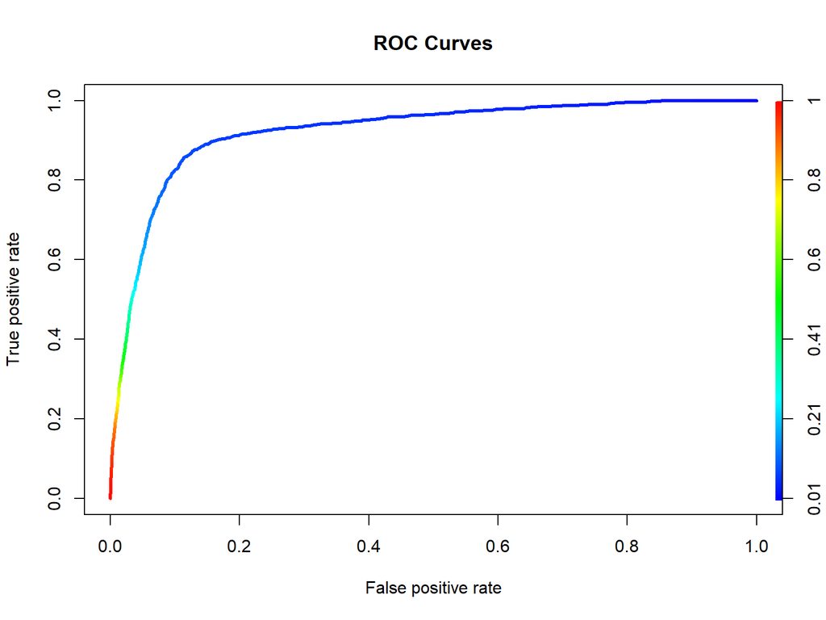

```r
library(ROCR)
svm.fit.prob <- svm(y~., data=dat_train, probability=TRUE)
pred.svm.prob <- predict(svm.fit.prob,dat_test,probability = TRUE)

prob <- attr(pred.svm.prob ,"probabilities")[,2]
pred.svm.trans <- prediction(prob, dat_test$y)


auc.logi <- performance(pred.svm.trans,'auc')@y.values[[1]]
plot(performance(pred.svm.trans, "tpr", "fpr"), colorize = T, lwd = 3, main = "ROC Curves")
```